# Lectura y preparación de datos para Data Mining

Antonio Montilla - NEOLAND

10/12/2019

# Descripción y enunciado

El objetivo de esta actividad es la gestión y preparación de datos. La gestión de datos es una parte muy importante de cualquier proceso de minería de datos, ya que los datos se deben preparar y preprocesar antes de iniciar el proceso de extracción de conocimiento. Esta tarea ilustra algunos de los procedimientos básicos con los que nos podemos encontrar para preparar los datos: analizar los tipos de datos, tranformar valores, detectar e eliminar outliers, hacer un muestreo, etcétera.

# Fichero de datos

El conjunto de datos con el que trabajaremos en esta actividad surge de la bases de datos disponibles en Kaggle . En concreto, los datos corresponden a los jugadores nombrados jugadores de la semana desde la temporada 1984-1985 hasta la temporada 2017-2018. Estos datos nos ofrecen múltiples posibilidades para consolidar los conocimientos y competencias de manipulación de datos, preprocesado y análisis descriptivo. El fichero NBA_player_of_the_week.csv se encuentra adjunto.

# Ingesta de datos

Actualmente el fichero se encuentra en la misma carpeta de datos RMD, está en adjunto. Se enviará nueva práctica similar con los datos de ingesta a través de scraping / API / base de datos para R y Python.

# Valoraciones

- se valorarán los trabajos por los detalles, no vale con el solo enviar un trozo de código, sino la explicación es fundamental
- explicar además los resumen de cada sección (carga, preparación, EDA, limpieza, nuevos atributos, discretización, split train-test)
- conclusiones y comparativas son los más importantes para comenzar con Data Mining.

**Diciembre 2019** 1 Cargar un juego de datos 1.1 Leer el fichero de datos “housePrices.txt” 2 Consulta de los datos cargados 2.1 Consulta de las etiquetas de los datos 2.2 Consulta de datos 3 Preparación de los datos 3.1 Cambiamos los identificadores de filas y columnas 3.2 Filtramos los datos 3.3 Modificamos el contenido de los datos 4 Split Train-Test 4.1 Generamos dos conjuntos de datos train y test 4.2 Guardamos los ficheros train y test en formato .csv

Para resolver la actividad, deberéis usar algunos comandos de R que quizás no os resulten demasiado familiares y que recomendamos que investiguéis. Estos son:

levels summary order/sort trimws sub table ifelse

## 1 Cargar un juego de datos

*Leer el fichero de datos “NBA_player_of_the_week.csv” y guardar los datos en un objeto con identificador denominado nba.*

```r
nba <- read.csv("NBA_player_of_the_week.csv",header = TRUE, stringsAsFactors=FALSE)
```

Como primer paso, creo un backup de la dataset

```r
nba_backup <- nba
```

## 2 Descripción de los datos

*Describir brevemente la estructura de los datos: qué tipo de datos contiene, número de filas y columnas y nombre de las columnas. Realizar un resumen descriptivo de los datos.*

### tipo de dato con class()

```r
class(nba)
```

```
## [1] "data.frame"
```

### tipo de estructura

```r
str(nba)
```

```
## 'data.frame':    1145 obs. of  13 variables:
##  $ Age              : int  29 23 28 37 28 26 24 25 25 25 ...
##  $ Conference       : chr  "" "" "" "" ...
##  $ Date             : chr  "Apr 14, 1985" "Apr 7, 1985" "Apr 1, 1985" "Mar 24, 1985" ...
##  $ Draft.Year       : int  1978 1982 1979 1969 1978 1980 1982 1981 1979 1982 ...
##  $ Height           : chr  "6-5" "6-6" "6-6" "7-2" ...
##  $ Player           : chr  "Micheal Ray Richardson" "Derek Smith" "Calvin Natt" "Kareem Abdul-Jabbar" ...
##  $ Position         : chr  "PG" "SG" "F" "C" ...
##  $ Season           : chr  "1984-1985" "1984-1985" "1984-1985" "1984-1985" ...
##  $ Season.short     : int  1985 1985 1985 1985 1985 1985 1985 1985 1985 1985 ...
##  $ Seasons.in.league: int  6 2 5 15 5 4 2 3 5 2 ...
##  $ Team             : chr  "New Jersey Nets" "Los Angeles Clippers" "Denver Nuggets" "Los Angeles Lakers" ...
##  $ Weight           : chr  "189" "205" "220" "225" ...
##  $ Real_value       : num  1 1 1 1 1 1 1 1 1 1 ...
```

- La dataset contiene 1.145 observaciones y 13 columnas detallando datos de los jugadores del NBA que fueron nombrados jugadores de la semana en las temporadas en el periodo 1984-2018.
- Las informacioón en las columnas muestra nombre del jugador, datos básicos (nombre, edad, peso, altura), equipo, posición que juega, fecha y temporada.
- Solo 5 de las 13 columnas continen valores numéricos (Age, Year, Season, Real_Value)
- Las 8 columnas restantes son caracteres que, dependiendo de su contenido, necesitarán ser factorizadas.

### head() es resumen de los 6 primeros resultados

```r
head(nba)
```

```
##   Age Conference         Date Draft.Year Height                 Player
## 1  29            Apr 14, 1985       1978    6-5 Micheal Ray Richardson
## 2  23             Apr 7, 1985       1982    6-6            Derek Smith
## 3  28             Apr 1, 1985       1979    6-6            Calvin Natt
## 4  37            Mar 24, 1985       1969    7-2    Kareem Abdul-Jabbar
## 5  28            Mar 17, 1985       1978    6-9             Larry Bird
## 6  26            Mar 10, 1985       1980    6-4       Darrell Griffith
##   Position    Season Season.short Seasons.in.league                 Team
## 1       PG 1984-1985         1985                 6      New Jersey Nets
## 2       SG 1984-1985         1985                 2 Los Angeles Clippers
## 3        F 1984-1985         1985                 5       Denver Nuggets
## 4        C 1984-1985         1985                15   Los Angeles Lakers
## 5       SF 1984-1985         1985                 5       Boston Celtics
## 6       SG 1984-1985         1985                 4            Utah Jazz
##   Weight Real_value
## 1    189          1
## 2    205          1
## 3    220          1
## 4    225          1
## 5    220          1
## 6    190          1
```

### con ls() extraemos el listado de las variables (columnas)

```r
ls(nba)
```

```
##  [1] "Age"               "Conference"        "Date"
##  [4] "Draft.Year"        "Height"            "Player"
##  [7] "Position"          "Real_value"        "Season"
## [10] "Season.short"      "Seasons.in.league" "Team"
## [13] "Weight"
```

### usando names() también extraemos las etiquetas de las columnas

```r
names(nba)
```

```
##  [1] "Age"               "Conference"        "Date"
##  [4] "Draft.Year"        "Height"            "Player"
##  [7] "Position"          "Season"            "Season.short"
## [10] "Seasons.in.league" "Team"              "Weight"
## [13] "Real_value"
```

### extraemos las etiquetas de las filas con row.names() o rownames()

```r
row.names(nba)
```

[output not shown]

[output cut: 113 more lines]

# 3.Preparación de la base de datos

## 3.1 Asignar NA a los valores ausentes en los datos de Conference.

```r
levels(nba$Conference)
```

```r
table(nba$Conference)
```

```
##
##      East West
##  384  381  380
```

384 de las observaciones de Conference son ausentes.

*creamos una lista conf*

```r
conf<-(nba$Conference)
```

*Asignar NA a los valores ausentes en los datos de Conference.*

```r
conf[conf==""] = NA
```

- *comprobaremos los nuevos datos asignados*

```r
str(conf)
```

```
##  chr [1:1145] NA NA NA NA NA NA NA NA NA NA NA NA NA NA NA NA NA NA NA ...
```

```r
table(conf)
```

```
## conf
## East West
##  381  380
```

## 3.2 Transformar los datos de Conference en variable categórica y mostrar la tabla de frecuencia.

```r
class(conf)
```

```
## [1] "character"
```

```r
prop.table(table(conf))
```

```
## conf
##     East     West
## 0.500657 0.499343
```

```r
table(conf)
```

```
## conf
## East West
##  381  380
```

La tabla confirma que no existe ningún dato vacío.

Como paso adicional, voy a introducir la columna *conf* en df *NBA* y luego eliminaré la columna *Conference*

```r
nba$Conf <- conf
nba <- subset(nba,select = -Conference)
ls(nba)
```

```
##  [1] "Age"               "Conf"              "Date"
##  [4] "Draft.Year"        "Height"            "Player"
##  [7] "Position"          "Real_value"        "Season"
## [10] "Season.short"      "Seasons.in.league" "Team"
## [13] "Weight"
```

## 3.4 Transformar las variables Height, Player, Position, Season, Team y Weight en variables categóricas.

```r
str(nba)
```

```
## 'data.frame':    1145 obs. of  13 variables:
##  $ Age              : int  29 23 28 37 28 26 24 25 25 25 ...
##  $ Date             : chr  "Apr 14, 1985" "Apr 7, 1985" "Apr 1, 1985" "Mar 24, 1985" ...
##  $ Draft.Year       : int  1978 1982 1979 1969 1978 1980 1982 1981 1979 1982 ...
##  $ Height           : chr  "6-5" "6-6" "6-6" "7-2" ...
##  $ Player           : chr  "Micheal Ray Richardson" "Derek Smith" "Calvin Natt" "Kareem Abdul-Jabbar" ...
##  $ Position         : chr  "PG" "SG" "F" "C" ...
##  $ Season           : chr  "1984-1985" "1984-1985" "1984-1985" "1984-1985" ...
##  $ Season.short     : int  1985 1985 1985 1985 1985 1985 1985 1985 1985 1985 ...
##  $ Seasons.in.league: int  6 2 5 15 5 4 2 3 5 2 ...
##  $ Team             : chr  "New Jersey Nets" "Los Angeles Clippers" "Denver Nuggets" "Los Angeles Lakers" ...
##  $ Weight           : chr  "189" "205" "220" "225" ...
##  $ Real_value       : num  1 1 1 1 1 1 1 1 1 1 ...
##  $ Conf             : chr  NA NA NA NA ...
```

## 3.5 Comprobar que estas variables no tienen valores perdidos.

```r
colSums(nba=="",na.rm = T)
```

```
##               Age              Date        Draft.Year            Height
##                 0                 0                 0                 0
##            Player          Position            Season      Season.short
##                 0                 0                 0                 0
## Seasons.in.league              Team            Weight        Real_value
##                 0                 0                 0                 0
##              Conf
##                 0
```

```r
table(nba$Conf)
```

```
##
## East West
##  381  380
```

```r
str(nba)
```

```
## 'data.frame':    1145 obs. of  13 variables:
##  $ Age              : int  29 23 28 37 28 26 24 25 25 25 ...
##  $ Date             : chr  "Apr 14, 1985" "Apr 7, 1985" "Apr 1, 1985" "Mar 24, 1985" ...
##  $ Draft.Year       : int  1978 1982 1979 1969 1978 1980 1982 1981 1979 1982 ...
##  $ Height           : chr  "6-5" "6-6" "6-6" "7-2" ...
##  $ Player           : chr  "Micheal Ray Richardson" "Derek Smith" "Calvin Natt" "Kareem Abdul-Jabbar" ...
##  $ Position         : chr  "PG" "SG" "F" "C" ...
##  $ Season           : chr  "1984-1985" "1984-1985" "1984-1985" "1984-1985" ...
##  $ Season.short     : int  1985 1985 1985 1985 1985 1985 1985 1985 1985 1985 ...
##  $ Seasons.in.league: int  6 2 5 15 5 4 2 3 5 2 ...
##  $ Team             : chr  "New Jersey Nets" "Los Angeles Clippers" "Denver Nuggets" "Los Angeles Lakers" ...
##  $ Weight           : chr  "189" "205" "220" "225" ...
##  $ Real_value       : num  1 1 1 1 1 1 1 1 1 1 ...
##  $ Conf             : chr  NA NA NA NA ...
```

## 3.6 Calcular el número de anyos que pasan entre que salio el jugador elegido en el draft y la temporada en la que fue jugador de la semana. Denomina la variable tiempo.

```r
nba$Tiempo <- (nba$Season.short - nba$Draft.Year)
```

## 3.7 ¿Cual es el número de años que más veces se repite entre que salen elegidos en el draft y se proclaman mejores jugadores? (moda de la variable tiempo)

```r
table(nba$Tiempo)
```

```
##
##   1   2   3   4   5   6   7   8   9  10  11  12  13  14  15  16  17  18
##  21  50  93 118 133 140 141 115  96  79  47  37  32  17   9   6   7   2
##  19
##   2
```

```r
summary(nba$Tiempo)
```

```
##    Min. 1st Qu.  Median    Mean 3rd Qu.    Max.
##   1.000   5.000   7.000   6.967   9.000  19.000
```

El número de años que más veces se repite entre que salen elegidos en el draft y se proclaman mejores jugadores es 7 años (141 observaciones de 1.145)

```r
table(nba$Height)
```

```
##
## 175cm 183cm 185cm 191cm 193cm 196cm 201cm 203cm 206cm 208cm 211cm 213cm
##     2     1     3    18     6    10    14    10     4     8     6     6
## 216cm 221cm  5-10  5-11   5-9   6-0   6-1  6-10  6-11   6-2   6-3   6-4
##     1     1     2     4     4    49    34    64   101    23    99    49
##   6-5   6-6   6-7   6-8   6-9   7-0   7-1   7-2   7-3   7-4   7-6
##    32   122   107   114   129    65    37    10     2     2     6
```

## 3.8 La altura de los jugadores está expresada en pies (aquellas con guión) y cm. Convertir la altura expresada en pies a centimetros https://www.piesametros.info/. Posteriormente, eliminar el texto “cm” de los datos de tipo altura y convertir la variable en numérica. Calcular media, desviación típica y boxplot.

```r
library(stringr) #Libreria para utilizar funciones de string (para buscar y remplazar)
table(nba$Height)
```

```
##
## 175cm 183cm 185cm 191cm 193cm 196cm 201cm 203cm 206cm 208cm 211cm 213cm
##     2     1     3    18     6    10    14    10     4     8     6     6
## 216cm 221cm  5-10  5-11   5-9   6-0   6-1  6-10  6-11   6-2   6-3   6-4
##     1     1     2     4     4    49    34    64   101    23    99    49
##   6-5   6-6   6-7   6-8   6-9   7-0   7-1   7-2   7-3   7-4   7-6
##    32   122   107   114   129    65    37    10     2     2     6
```

```r
#Primero remplazo valores que están en pies por equivalente en cm
nba$Height[nba$Height=='5-10'] = "178cm"
nba$Height[nba$Height=='5-11'] = "180cm"
nba$Height[nba$Height=='5-9'] = "178cm"
nba$Height[nba$Height=='6-0'] = "183cm"
nba$Height[nba$Height=='6-1'] = "185cm"
nba$Height[nba$Height=='6-2'] = "188cm"
nba$Height[nba$Height=='6-3'] = "191cm"
nba$Height[nba$Height=='6-4'] = "193cm"
nba$Height[nba$Height=='6-5'] = "196cm"
nba$Height[nba$Height=='6-6'] = "198cm"
nba$Height[nba$Height=='6-7'] = "201cm"
nba$Height[nba$Height=='6-8'] = "203cm"
nba$Height[nba$Height=='6-9'] = "206cm"
nba$Height[nba$Height=='6-10'] = "208m"
nba$Height[nba$Height=='6-11'] = "209cm"
nba$Height[nba$Height=='7-0'] = "215cm"
nba$Height[nba$Height=='7-1'] = "218cm"
nba$Height[nba$Height=='7-2'] = "221cm"
nba$Height[nba$Height=='7-3'] = "224cm"
nba$Height[nba$Height=='7-4'] = "227cm"
nba$Height[nba$Height=='7-6'] = "234cm"
#Segundo elimino el caracter "cm"
nba$Height <- stringr::str_remove(nba$Height, 'cm')
#Tercero convierto la columna a numérico y genero estadísticas desciptiva y boxplot
nba$Height <- as.numeric(nba$Height)
table(nba$Height)
```

```
##
## 175 178 180 183 185 188 191 193 196 198 201 203 206 208 209 211 213 215
##   2   6   4  50  37  23 117  55  42 122 121 124 133   8 101   6   6  65
## 216 218 221 224 227 234
##   1  37  11   2   2   6
```

```r
summary(nba$Height)
```

```
##    Min. 1st Qu.  Median    Mean 3rd Qu.    Max.    NA's
##   175.0   193.0   201.0   200.7   206.0   234.0      64
```

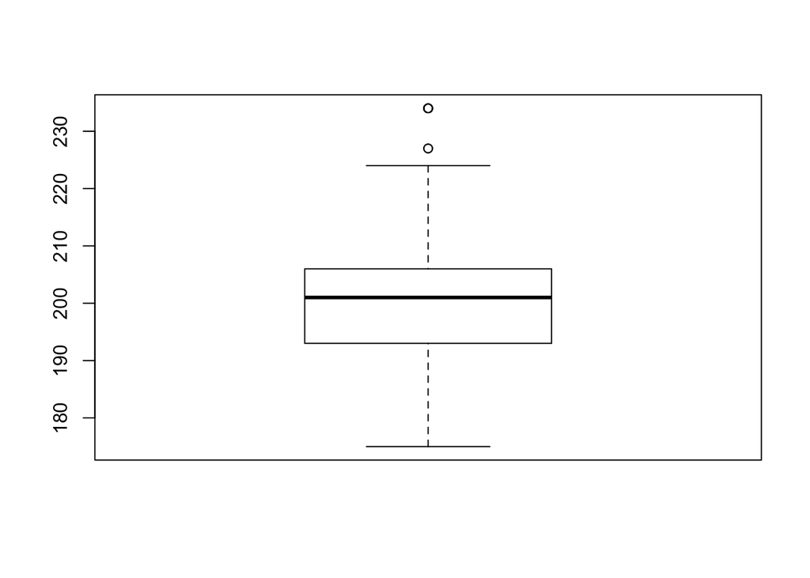

```r
boxplot(nba$Height)
```

### 3.9

El peso de los jugadores está expresada en libras y kg. Convertir el peso expresado en kgs en libras https://www.metric-conversions.org/es/peso/kilogramos-a-libras.htm. Convertir la variable en numérica.Calcular media, desviación típica y boxplot.

```r
#Primero observando la composicion de la columna
table(nba$Weight)
```

```
##
## 100kg 101kg 102kg 104kg 105kg 106kg 107kg 109kg 111kg 113kg 114kg 115kg
##    20     2     1     3     3     1     1     3     2    13     2     3
## 116kg 118kg 120kg 122kg 127kg   150   163   165   168   170   175   178
##     1     1     1     2     1     1     2    24     1    15    20     8
##   180   184   185   186   188   189   190   191   193   194   195   196
##    24     5    35     3     1     2    30     7     6     1    19     5
##   198   199   200   205   208   209   210   211   212   215   217   218
##     3     2    38    31     3     1    59     5    33    48     1     1
##   220   221   222   223   225   228   229   230   231   232   233   235
##    70     2     2     1    22    20     4    15     1     1     3    35
##   240   242   244   245   246   247   249   250   251   252   253   254
##    99     1     1    48     2     1     1   106     7    11     1     5
##   255   259   260   261   265   266   268   270   279   280   285   289
##    25     1    30     2    45     6     3     4     3     6     3     7
##   307   310   325  79kg  83kg  84kg  85kg  86kg  88kg  91kg  94kg  95kg
##     1     6    20     3     1     2     1     7     4     6     1     5
```

```r
#Segundo creo nueva columna con las observaciones que están en kg
nba$Peso_kg <- ifelse(grepl("kg",nba$Weight), nba$Weight, 0)
#Tercero creo otra columna donde remuevo el caracter kg
nba$Peso_kg_c <- stringr::str_remove(nba$Peso_kg, 'kg')
#Cuarto convierto los valores de kg a libras en nueva columna _WeightF_
nba$Peso_kg_c <- as.numeric(nba$Peso_kg_c)
nba$WeightF <- round((nba$Peso_kg_c)*2.205)
#Quinto sustituyo los valores de _WeightF_ == 0 por los originales en Weight (que están en libras)
nba$WeightF[nba$WeightF==0] = nba$Weight
#Convierto en numérica y muestro estadísticas básicas
nba$WeightF <- as.numeric(nba$WeightF)
table(nba$WeightF)
```

```
##
## 150 163 165 168 170 174 175 178 180 183 184 185 186 187 188 189 190 191
##   1   2  24   1  15   3  20   8  24   1   5  37   3   1   1   2  37   7
## 193 194 195 196 198 199 200 201 205 207 208 209 210 211 212 215 217 218
##   6   5  19   5   3   2  38   6  31   1   3   6  59   5  33  48   1   1
## 220 221 222 223 225 228 229 230 231 232 233 234 235 236 240 242 244 245
##  90   2   2   3  23  20   7  15   1   4   3   1  35   1 102   1   1  50
## 246 247 249 250 251 252 253 254 255 256 259 260 261 265 266 268 269 270
##   2   1  14 106   9  11   1   8  25   1   1  31   2  46   6   3   2   4
## 279 280 285 289 307 310 325
##   3   7   3   7   1   6  20
```

```r
summary(nba$WeightF)
```

```
##    Min. 1st Qu.  Median    Mean 3rd Qu.    Max.
##     150     205     225     226     250     325
```

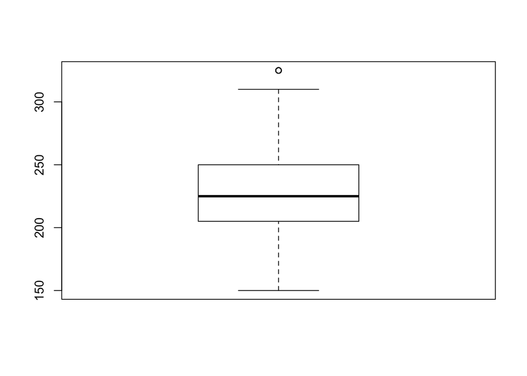

```r
boxplot(nba$WeightF)
```

```r
#Finalmente elimino las columnas que ya no hacen falta
nba <- subset(nba,select = -c(Peso_kg, Peso_kg_c))
```

# 4 Información sobre posiciones en el campo y equipos.

## 4.1 Fusionar las categorias de posición en el campo F,F-C y FC en la categoría genérica Forward. Fusionar las categorias G,G-F y GF en la categoria genérica Guard. Renombrar la categoría ‘PG’ como ‘Point Guard’, ‘SG’ como ‘Shooting Guard’, ‘SF’ como ‘Small Forward’, ‘PF’ como ‘Power Forward’ y ‘C’ como ‘Center’.

```r
table(nba$Position)
```

```
##
##   C   F F-C  FC   G G-F  GF  PF  PG  SF  SG
## 158 125   9  83 178   3  47 139 120 119 164
```

```r
nba$Forward <- ifelse(nba$Position=="C", "Center", "")
nba$Forward[nba$Position=="PF"] = "Power Forward"
nba$Forward[nba$Position=="SF"] = "Small Forward"
nba$Forward[nba$Position=="SG"] = "Shooting Guard"
nba$Forward[nba$Position=="PG"] = "Point Guard"
nba$Forward[nba$Position=="G"] = "Guard"
nba$Forward[nba$Position=="G-F"] = "Guard"
nba$Forward[nba$Position=="GF"] = "Guard"
nba$Forward[nba$Position=="F"] = "Forward"
nba$Forward[nba$Position=="F-C"] = "Forward"
nba$Forward[nba$Position=="FC"] = "Forward"
table(nba$Forward)
```

```
##
##         Center        Forward          Guard    Point Guard  Power Forward
##            158            217            228            120            139
## Shooting Guard  Small Forward
##            164            119
```

## 4.2 ¿En que posición ha sido más veces los jugadores de la semana nombrados?

```r
table(nba$Forward)
```

```
##
##         Center        Forward          Guard    Point Guard  Power Forward
##            158            217            228            120            139
## Shooting Guard  Small Forward
##            164            119
```

La posición de Guard ha sido más veces os jugadores de la semana nombrados

## 4.3 ¿Cuántos equipos distintos hay?

```r
length(unique(nba$Team))
```

```
## [1] 35
```

Existen 35 equipos distintos en la data set

## 4.4 ¿Cuáles son los cinco equipos que más veces han sido nombrados sus jugadores como jugador de la semana?

```r
#Creando una nueva variable con datos de los equipos
team2 <- aggregate(data.frame(count = nba$Team), list(value = nba$Team), length)
#Ordenando de manera descendente
head(team2[order(-team2$count),], n = 5)
```

```
##                  value count
## 15  Los Angeles Lakers    71
## 30   San Antonio Spurs    61
## 7  Cleveland Cavaliers    59
## 17          Miami Heat    57
## 12     Houston Rockets    56
```

Los cinco equipos que más veces han sido nombrados sus jugadores como jugador de la semana son: Los Angeles Lakers (71 veces), San Antonio Spurs (61), Cleveland Cavaliers (59), Miami Heat (57) y Houston Rockets (56).

# 5 Información sobre jugadores. Estadísticos descriptivos.

## 5.1 Crear una base datos denominada nba.unique en la que no se repita el nombre de ningún jugador.Trabajar a partir de ahora con esta base de datos.

```r
nba.unique <- nba[!duplicated(nba[,'Player']),]
str(nba.unique)
```

```
## 'data.frame':    274 obs. of  16 variables:
##  $ Age              : int  29 23 28 37 28 26 24 25 25 25 ...
##  $ Date             : chr  "Apr 14, 1985" "Apr 7, 1985" "Apr 1, 1985" "Mar 24, 1985" ...
##  $ Draft.Year       : int  1978 1982 1979 1969 1978 1980 1982 1981 1979 1982 ...
##  $ Height           : num  196 198 198 221 206 193 191 198 206 201 ...
##  $ Player           : chr  "Micheal Ray Richardson" "Derek Smith" "Calvin Natt" "Kareem Abdul-Jabbar" ...
##  $ Position         : chr  "PG" "SG" "F" "C" ...
##  $ Season           : chr  "1984-1985" "1984-1985" "1984-1985" "1984-1985" ...
##  $ Season.short     : int  1985 1985 1985 1985 1985 1985 1985 1985 1985 1985 ...
##  $ Seasons.in.league: int  6 2 5 15 5 4 2 3 5 2 ...
##  $ Team             : chr  "New Jersey Nets" "Los Angeles Clippers" "Denver Nuggets" "Los Angeles Lakers" ...
##  $ Weight           : chr  "189" "205" "220" "225" ...
##  $ Real_value       : num  1 1 1 1 1 1 1 1 1 1 ...
##  $ Conf             : chr  NA NA NA NA ...
##  $ Tiempo           : int  7 3 6 16 7 5 3 4 6 3 ...
##  $ WeightF          : num  189 205 220 225 220 190 170 232 255 200 ...
##  $ Forward          : chr  "Point Guard" "Shooting Guard" "Forward" "Center" ...
```

## 5.2 Listar el nombre de los 10 jugadores más bajos que han sido nombrados alguna vez jugadores de la semana. No debe repetirse ningún nombre.

```r
#Primero creo un subset con columnas _Height_ y _Player_
Altura <- data.frame(nba.unique$Height, nba.unique$Player)
#Seguno se orderna de manera ascendente por _Height_ y extraemos los primeros 10
head(Altura[order(Altura$nba.unique.Height),], n = 10)
```

```
##     nba.unique.Height nba.unique.Player
## 51                178     Michael Adams
## 227               178     Nate Robinson
## 245               178     Isaiah Thomas
## 104               180   Terrell Brandon
## 220               180         Ty Lawson
## 54                183      Tim Hardaway
## 85                183    Kenny Anderson
## 97                183      Elliot Perry
## 105               183     Allen Iverson
## 115               183 Darrell Armstrong
```

## 5.3 Listar el nombre de los 10 jugadores más altos que han sido nombrados y mostrar su altura. No debe repetirse ningún nombre.

```r
#Ahora ordernamos por altura de manera descendente y extraemos los primeros 10
head(Altura[order(-Altura$nba.unique.Height),], n = 10)
```

```
##     nba.unique.Height   nba.unique.Player
## 155               234            Yao Ming
## 91                227           Rik Smits
## 99                224     Arvydas Sabonis
## 153               224  Zydrunas Ilgauskas
## 4                 221 Kareem Abdul-Jabbar
## 79                221     Dikembe Mutombo
## 274               221  Kristaps Porzingis
## 52                218      David Robinson
## 84                218    Shaquille O'Neal
## 89                218         Vlade Divac
```

# 6 Eliminación de outliers.

## 6.1 Eliminar los outliers de la variable peso (Weight) y guardar en un data frame nba.avg

```r
#Primero creo nueva columna individual nba.avg con _WeightF_
nba.avg <- data.frame(nba.unique$WeightF)
str(nba.avg)
```

```
## 'data.frame':    274 obs. of  1 variable:
##  $ nba.unique.WeightF: num  189 205 220 225 220 190 170 232 255 200 ...
```

```r
summary(nba.avg$nba.unique.WeightF)
```

```
##    Min. 1st Qu.  Median    Mean 3rd Qu.    Max.
##   150.0   195.0   220.0   219.1   240.0   325.0
```

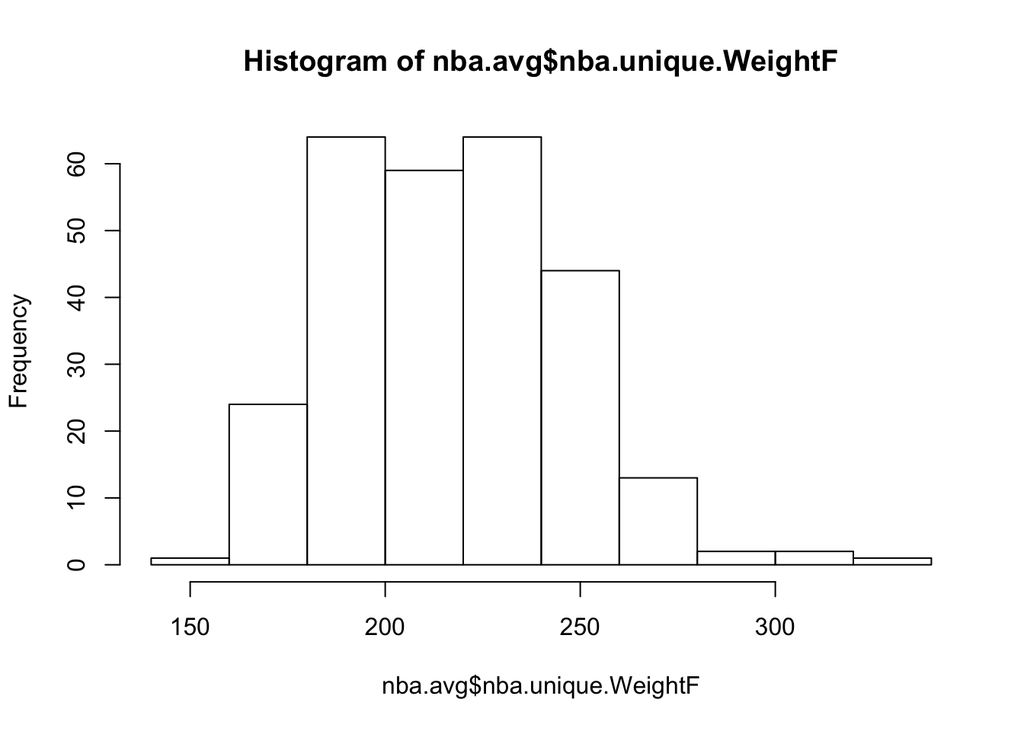

```r
hist(nba.avg$nba.unique.WeightF)
```

```r
#Segundo calculo los quartiles para poder indentificar outliers
quantile(nba.avg$nba.unique.WeightF)
```

```
##   0%  25%  50%  75% 100%
##  150  195  220  240  325
```

```r
cuartiles <- quantile(nba.avg$nba.unique.WeightF)
Q1 <- cuartiles[2]
Q3 <- cuartiles[4]
IQR <- Q3 - Q1
nba.avg$outliers_w <- ifelse(nba.avg$nba.unique.WeightF>(Q3 + 1.5*IQR), 1, 0)
nba.avg$outliers_w[nba.avg$nba.unique.WeightF<(Q1 - 1.5*IQR)] = 1
table(nba.avg$outliers_w)
```

```
##
##   0   1
## 272   2
```

```r
nba.avg <- nba.avg[!(nba.avg$outliers_w == 1),]
table(nba.avg$outliers_w)
```

```
##
##   0
## 272
```

## 6.2 Comparar los boxplots de los datos originales en nba.unique y de los datos del peso de nba.avg

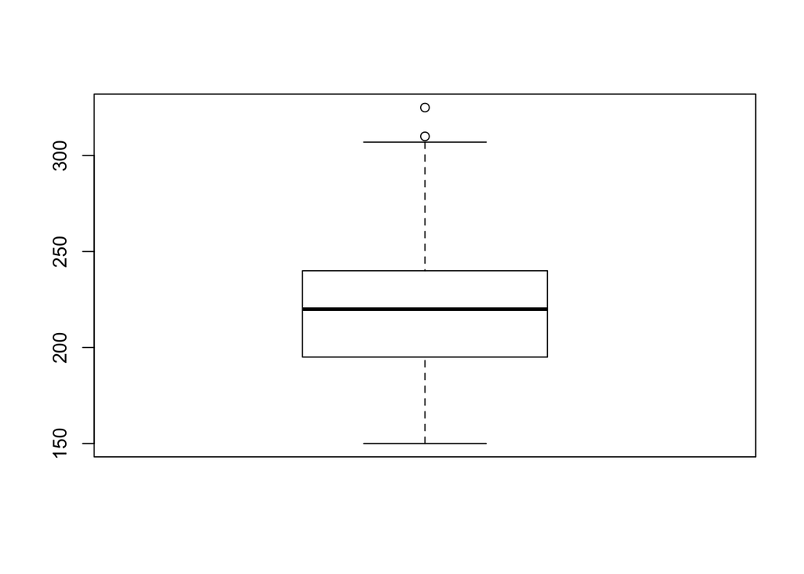

```r
boxplot(nba.unique$WeightF)
```

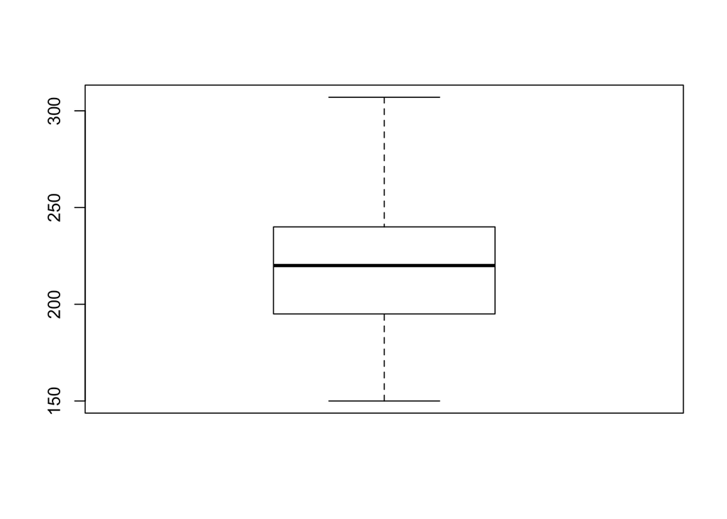

```r
boxplot(nba.avg$nba.unique.WeightF)
```

## 6.3 Interpretar los resultados

```r
summary(nba.unique$WeightF)
```

```
##    Min. 1st Qu.  Median    Mean 3rd Qu.    Max.
##   150.0   195.0   220.0   219.1   240.0   325.0
```

```r
summary(nba.avg$nba.unique.WeightF)
```

```
##    Min. 1st Qu.  Median    Mean 3rd Qu.    Max.
##   150.0   195.0   220.0   218.3   240.0   307.0
```

Con la eliminación de los outliers con pesos superiores a 307.5, se han reducido el numero de elementos en el segundo dataframe nba.avg. Los elementos se han reducido de 274 a 272. Con esto, la media de la variable se ha reducido de 219.1 a 218.3, reflejando mas apropiadamente el conjunto de los datos. El primer y el tercer cuartil, sin embargo, no han variado.

# 7 Clasificación de jugadores

## 7.1 Añadir una columna al conjunto de datos denominada “Altura” que contenga los valores: {“bajo”, “normal”, “alto”}. La asignación del valor depende de la altura de cada jugador. Se asigna:

- bajo: los 50 jugadores más bajos
- alto: los 50 jugadores más altos
- normal: el resto de jugadores

```r
#Primero creo nueva columna con el ranking de _Height_ en forma ascedente
nba.unique$Altura_rank <- NA
nba.unique$Altura_rank[order(nba.unique$Height)] <- 1:nrow(nba.unique)
#Segundo creo columna _Altura_ usando como referencia el ranking, según criterio
nba.unique$Altura <- ifelse(nba.unique$Altura_rank>50, "normal", "bajo")
nba.unique$Altura[nba.unique$Altura_rank>224] = "alto"
#Compruebo los datos
table(nba.unique$Altura)
```

```
##
##   alto   bajo normal
##     50     50    174
```

## 7.2 Añadir una columna al conjunto de datos denominada “Peso” que contenga los valores: {“bajo”, “normal”, “alto”}. La asignación del valor depende del peso de cada jugador. Se asigna:

- bajo: los 50 jugadores con menor peso
- alto: los 50 jugadores con mayor peso
- normal: el resto de jugadores

```r
#Primero creo nueva columna con el ranking de _WeightF_ en forma ascedente
nba.unique$Peso_rank <- NA
nba.unique$Peso_rank[order(nba.unique$WeightF)] <- 1:nrow(nba.unique)
#Segundo creo columna _pESI_ usando como referencia el ranking, según criterio
nba.unique$Peso <- ifelse(nba.unique$Peso_rank>50, "normal", "bajo")
nba.unique$Peso[nba.unique$Peso_rank>224] = "alto"
#Compruebo los datos
table(nba.unique$Peso)
```

```
##
##   alto   bajo normal
##     50     50    174
```

## 7.3 Calcular la media y desviación típica del peso (Weight) según la clasificación de altura de los jugadores.

```r
mean(nba.unique$WeightF[nba.unique$Altura == 'bajo'])
```

```
## [1] 182.86
```

```r
sd(nba.unique$WeightF[nba.unique$Altura == 'bajo'])
```

```
## [1] 12.33546
```

```r
mean(nba.unique$WeightF[nba.unique$Altura == 'normal'])
```

```
## [1] 220.9828
```

```r
sd(nba.unique$WeightF[nba.unique$Altura == 'normal'])
```

```
## [1] 23.25791
```

```r
mean(nba.unique$WeightF[nba.unique$Altura == 'alto'])
```

```
## [1] 248.64
```

```r
sd(nba.unique$WeightF[nba.unique$Altura == 'alto'])
```

```
## [1] 22.74146
```

## 7.4 Realizar un boxplot del peso (Weight) según la clasificación de altura del jugador. Los boxplots deben estar ordenados de menos a mayor altura.

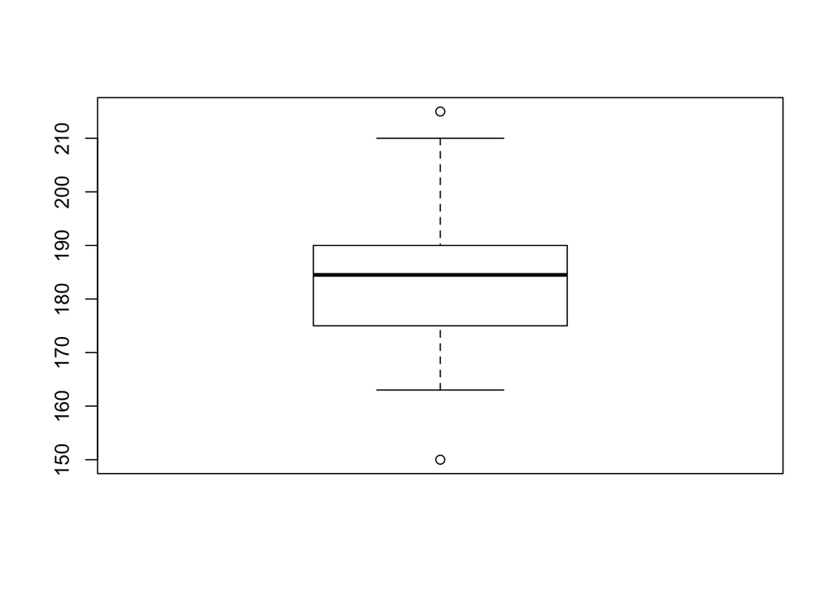

```r
boxplot(nba.unique$WeightF[nba.unique$Altura == 'bajo'])
```

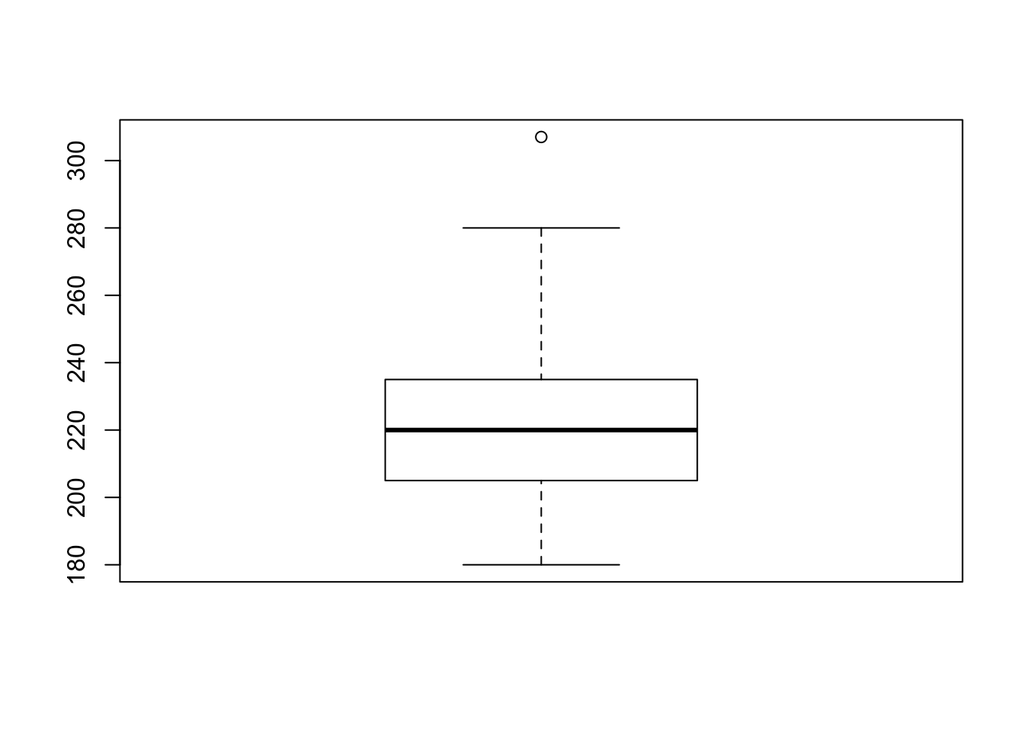

```r
boxplot(nba.unique$WeightF[nba.unique$Altura == 'normal'])
```

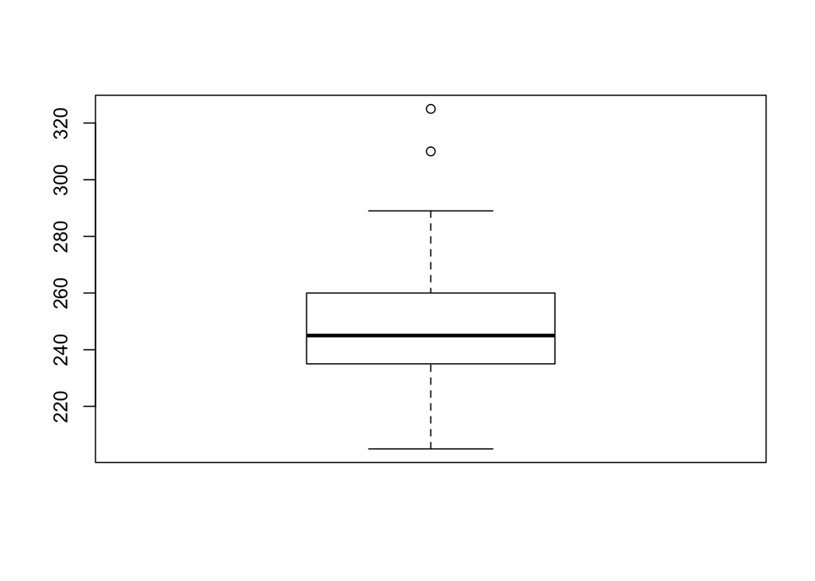

```r
boxplot(nba.unique$WeightF[nba.unique$Altura == 'alto'])
```

## 7.5 Hacer un listado con el nombre de jugadores que tienen una altura ‘normal’ y un peso ‘alto’. Ordenar alfabéticamente por nombre.

```r
#Primero creo una columna dummy que tome 1 si las condiciones se cumplen
nba.unique$Subset1 <- ifelse((nba.unique$Altura=="normal" & nba.unique$Peso=='alto'), 1, 0)
#Segundo creo nueva df con las columnas implicadas
Subset1 <- data.frame(nba.unique$Player, nba.unique$Altura, nba.unique$Peso, nba.unique$Subset1)

#Tercero elimino observaciones donde condiciones no se cumplen
Subset1 <- Subset1[!(Subset1$nba.unique.Subset1 == 0),]

#Cuarto se orderna de manera ascendente por _player_
head(Subset1[order(Subset1$nba.unique.Player),], n = 50)
```

```
##     nba.unique.Player nba.unique.Altura nba.unique.Peso nba.unique.Subset1
## 262    Andre Drummond            normal            alto                  1
## 146    Antoine Walker            normal            alto                  1
## 159     Carlos Boozer            normal            alto                  1
## 23    Charles Barkley            normal            alto                  1
## 200        David West            normal            alto                  1
## 240  DeMarcus Cousins            normal            alto                  1
## 191     Dwight Howard            normal            alto                  1
## 140       Elton Brand            normal            alto                  1
## 263  Hassan Whiteside            normal            alto                  1
## 151   Jamaal Magloire            normal            alto                  1
## 95     Jamal Mashburn            normal            alto                  1
## 238   Jared Sullinger            normal            alto                  1
## 265       Joel Embiid            normal            alto                  1
## 33        Karl Malone            normal            alto                  1
## 214 LaMarcus Aldridge            normal            alto                  1
## 68      Larry Johnson            normal            alto                  1
## 166      LeBron James            normal            alto                  1
## 9       Magic Johnson            normal            alto                  1
## 186       Mehmet Okur            normal            alto                  1
## 148 Metta World Peace            normal            alto                  1
## 269      Nikola Jokic            normal            alto                  1
## 223    Nikola Pekovic            normal            alto                  1
## 87      Oliver Miller            normal            alto                  1
## 239      Paul Millsap            normal            alto                  1
## 110        Tim Duncan            normal            alto                  1
## 212     Zach Randolph            normal            alto                  1
```

En total hay 26 observaciones con altura normal y peso alto, ordenadas alfabéticamente (por nombre) en la table de resultado

# 8 Preparación de datos para la minería de datos

> Se desea aplicar un modelo de minería de datos. Seguir los pasos siguientes:

## 8.1 Incluir en el conjunto de datos original (nba) la clasificación del peso y la altura de los jugadores contenida en la base de datos nba.unique. Denomina este conjunto de datos dataset

```r
dataset <- nba
#Repitiendo los pasos de Altura
dataset$Altura_rank <- NA
dataset$Altura_rank[order(dataset$Height)] <- 1:nrow(dataset)
dataset$Altura <- ifelse(dataset$Altura_rank>50, "normal", "bajo")
dataset$Altura[dataset$Altura_rank>(nrow(dataset)-50)] = "alto"
table(dataset$Altura)
```

```
##
##   alto   bajo normal
##     50     50   1045
```

```r
#Repitiendo los pasos de Peso
dataset$Peso_rank <- NA
dataset$Peso_rank[order(dataset$Weight)] <- 1:nrow(dataset)
dataset$Peso <- ifelse(dataset$Peso_rank>50, "normal", "bajo")
dataset$Peso[dataset$Peso_rank>(nrow(dataset)-50)] = "alto"
table(dataset$Peso)
```

```
##
##   alto   bajo normal
##     50     50   1045
```

## 8.2 Generar un conjunto de datos donde no se incluya la variable ‘Season’ ni la variable ‘Real_value’. Denomina este conjunto de datos dataset2

```r
dataset2 <- subset(dataset, select = -c(Season, Real_value))
```

## 8.3 Verificar que no hay ningún valor NA. Si existen, eliminar las filas que los contienen. Denomina el conjunto de datos data.limpio.

```r
colSums(is.na(dataset2))
```

```
##               Age              Date        Draft.Year            Height
##                 0                 0                 0                64
##            Player          Position      Season.short Seasons.in.league
##                 0                 0                 0                 0
##              Team            Weight              Conf            Tiempo
##                 0                 0               384                 0
##           WeightF           Forward       Altura_rank            Altura
##                 0                 0                 0                 0
##         Peso_rank              Peso
##                 0                 0
```

```r
datos.limpio <- na.omit(dataset2)
str(datos.limpio)
```

```
## 'data.frame':    724 obs. of  18 variables:
##  $ Age              : int  24 25 27 23 28 25 22 25 29 29 ...
##  $ Date             : chr  "Apr 7, 2002" "Apr 7, 2002" "Mar 31, 2002" "Mar 31, 2002" ...
##  $ Draft.Year       : int  1998 1997 1996 1999 1994 1997 1997 1997 1995 1992 ...
##  $ Height           : num  201 209 206 201 193 209 203 209 206 218 ...
##  $ Player           : chr  "Paul Pierce" "Tim Duncan" "Ben Wallace" "Shawn Marion" ...
##  $ Position         : chr  "SF" "FC" "FC" "F" ...
##  $ Season.short     : int  2002 2002 2002 2002 2002 2002 2002 2002 2002 2002 ...
##  $ Seasons.in.league: int  3 4 5 2 7 4 4 4 6 9 ...
##  $ Team             : chr  "Boston Celtics" "San Antonio Spurs" "Detroit Pistons" "Phoenix Suns" ...
##  $ Weight           : chr  "235" "250" "240" "228" ...
##  $ Conf             : chr  "East" "West" "East" "West" ...
##  $ Tiempo           : int  4 5 6 3 8 5 5 5 7 10 ...
##  $ WeightF          : num  235 250 240 228 210 250 210 250 240 325 ...
##  $ Forward          : chr  "Small Forward" "Forward" "Forward" "Forward" ...
##  $ Altura_rank      : int  507 861 764 508 253 862 602 863 765 1052 ...
##  $ Altura           : chr  "normal" "normal" "normal" "normal" ...
##  $ Peso_rank        : int  637 850 696 605 371 851 372 852 697 1108 ...
##  $ Peso             : chr  "normal" "normal" "normal" "normal" ...
##  - attr(*, "na.action")= 'omit' Named int  1 2 3 4 5 6 7 8 9 10 ...
##   ..- attr(*, "names")= chr  "1" "2" "3" "4" ...
```

```r
colSums(is.na(datos.limpio))
```

```
##               Age              Date        Draft.Year            Height
##                 0                 0                 0                 0
##            Player          Position      Season.short Seasons.in.league
##                 0                 0                 0                 0
##              Team            Weight              Conf            Tiempo
##                 0                 0                 0                 0
##           WeightF           Forward       Altura_rank            Altura
##                 0                 0                 0                 0
##         Peso_rank              Peso
##                 0                 0
```

- La dataframe ‘dataset2’ contiene 64 NAs en la columna *Height* y 384 NAs en columna *Conf*
- Se eliminan los NAs y se crea una nueva dataframe llamada ‘datos.limpio’

```r
#install.packages(caTools)
require(caTools) # para el train-test utilizamos la libreia(caTools)
#m <- short nrw (now (X)* 0.70)
#set.seed (1,2,3)
#train <- X[muestra]
#test <- X[-muestra]
```